# Experimentation and uplift testing

## Task 2

For this part of the project we will be examining the performance in trial vs control stores to provide a recommendation for each location based on our insight

- The trial syore are: 77, 86 and 88.

**Select control stores** - explore the data and define metrics for your control store selection - think about what would make them a control store. Look at the drivers and make sure you visualize these in a graph to better determine if they are suited. For this plece it may even be worth creating a function to help you

Create a measure to compare different control stores to each of the trial stores, to do this write a function to reduce having to re-do the analysis for each trial store. Consider using Pearson correlations or a metric such as a magnitude distance e.g 1 - (Observed distance - minimum distance)/(Maximum distance - minimum distance) as a measure

**Assessment of the trial** - this one should give you some interesting insights into each of the stores, check each trial store individually in comparision with the control store to get a clear view of its overal performance. We want to know if the trial store were successful or not

**Collare findings** - summerie your findings for each store and provide an recommendation that we can share with Julia outlining the impact on sales during the trial period

You are part of Quantium’s retail analytics team and have been approached by your client, the Category Manager for Chips, has asked us to test the impact of the new trial layouts with a data driven recommendation to whether or not the trial layout should be rolled out to all their stores.

Once you have selected your control stores, compare each trial and control pair during the trial period. You want to test if total sales are significantly different in the trial period and if so, check if the driver of change is more purchasing customers or more purchases per customers etc.

- total sales revenue
- total number of customers
- average number of transactions per customer

```python
import pandas as pd
import seaborn as sns
import matplotlib.pyplot as plt
%matplotlib inline
from datetime import time
from datetime import datetime
import numpy as np
```

## DATA READ

```python
merge = pd.read_csv('merged_data.csv')
merge.head(5)
```

|  | Unnamed: 0 | DATE | STORE_NBR | LYLTY_CARD_NBR | TXN_ID | PROD_NBR | PROD_NAME | PROD_QTY | TOT_SALES | CHIP_PROD | PACK_SIZE | BRAND | LIFESTAGE | PREMIUM_CUSTOMER |
| --- | --- | --- | --- | --- | --- | --- | --- | --- | --- | --- | --- | --- | --- | --- |
| 0 | 0 | 2018-10-17 | 1 | 1000 | 1 | 5 | Natural Chip Compny SeaSalt175g | 2 | 6.0 | Chips | 175 | Natural | YOUNG SINGLES/COUPLES | Premium |
| 1 | 1 | 2019-05-14 | 1 | 1307 | 348 | 66 | CCs Nacho Cheese 175g | 3 | 6.3 | Chips | 175 | CCs | MIDAGE SINGLES/COUPLES | Budget |
| 2 | 2 | 2019-05-20 | 1 | 1343 | 383 | 61 | Smiths Crinkle Cut Chips Chicken 170g | 2 | 2.9 | Chips | 170 | Smiths | MIDAGE SINGLES/COUPLES | Budget |
| 3 | 3 | 2018-08-17 | 2 | 2373 | 974 | 69 | Smiths Chip Thinly S/Cream&Onion 175g | 5 | 15.0 | Chips | 175 | Smiths | MIDAGE SINGLES/COUPLES | Budget |
| 4 | 4 | 2018-08-18 | 2 | 2426 | 1038 | 108 | Kettle Tortilla ChpsHny&Jlpno Chili 150g | 3 | 13.8 | Chips | 150 | Kettle | MIDAGE SINGLES/COUPLES | Budget |

```python
merge.columns
```

```
Index(['Unnamed: 0', 'DATE', 'STORE_NBR', 'LYLTY_CARD_NBR', 'TXN_ID',
       'PROD_NBR', 'PROD_NAME', 'PROD_QTY', 'TOT_SALES', 'CHIP_PROD',
       'PACK_SIZE', 'BRAND', 'LIFESTAGE', 'PREMIUM_CUSTOMER'],
      dtype='object')
```

```python
del merge['Unnamed: 0']
```

```python
merge.sort_values(by='DATE', ascending=True)
```

[output not shown]

246517 rows × 14 columns

The client has selected store numbers 77, 86 and 88 as trial stores and want control stores to be established stores that are operational for the entire observation period. We would want to match trial stores to control stores that are similar to the trial store prior to the trial period of Feb 2019 in terms of :

- Monthly overall sales revenue
- Monthly number of customers
- Monthly number of transactions per customer

Let's first create the metrics of interest and filter to stores that are present throughout the pre-trial period.

```python
merge.info()
```

```
<class 'pandas.core.frame.DataFrame'>
RangeIndex: 246740 entries, 0 to 246739
Data columns (total 13 columns):
 #   Column            Non-Null Count   Dtype
---  ------            --------------   -----
 0   DATE              246740 non-null  object
 1   STORE_NBR         246740 non-null  int64
 2   LYLTY_CARD_NBR    246740 non-null  int64
 3   TXN_ID            246740 non-null  int64
 4   PROD_NBR          246740 non-null  int64
 5   PROD_NAME         246740 non-null  object
 6   PROD_QTY          246740 non-null  int64
 7   TOT_SALES         246740 non-null  float64
 8   CHIP_PROD         246740 non-null  object
 9   PACK_SIZE         246740 non-null  int64
 10  BRAND             246740 non-null  object
 11  LIFESTAGE         246740 non-null  object
 12  PREMIUM_CUSTOMER  246740 non-null  object
dtypes: float64(1), int64(6), object(6)
memory usage: 24.5+ MB
```

```python
merge['DATE']=pd.to_datetime(merge['DATE'])
merge['MONTH_YEAR']=merge['DATE'].dt.strftime('%m/%Y')
merge['MONTH_YEAR']
```

```
0         10/2018
1         05/2019
2         05/2019
3         08/2018
4         08/2018
           ...
246735    03/2019
246736    08/2018
246737    11/2018
246738    12/2018
246739    09/2018
Name: MONTH_YEAR, Length: 246740, dtype: object
```

```python
merge.head(5)
```

|  | DATE | STORE_NBR | LYLTY_CARD_NBR | TXN_ID | PROD_NBR | PROD_NAME | PROD_QTY | TOT_SALES | CHIP_PROD | PACK_SIZE | BRAND | LIFESTAGE | PREMIUM_CUSTOMER | MONTH_YEAR |
| --- | --- | --- | --- | --- | --- | --- | --- | --- | --- | --- | --- | --- | --- | --- |
| 0 | 2018-10-17 | 1 | 1000 | 1 | 5 | Natural Chip Compny SeaSalt175g | 2 | 6.0 | Chips | 175 | Natural | YOUNG SINGLES/COUPLES | Premium | 10/2018 |
| 1 | 2019-05-14 | 1 | 1307 | 348 | 66 | CCs Nacho Cheese 175g | 3 | 6.3 | Chips | 175 | CCs | MIDAGE SINGLES/COUPLES | Budget | 05/2019 |
| 2 | 2019-05-20 | 1 | 1343 | 383 | 61 | Smiths Crinkle Cut Chips Chicken 170g | 2 | 2.9 | Chips | 170 | Smiths | MIDAGE SINGLES/COUPLES | Budget | 05/2019 |
| 3 | 2018-08-17 | 2 | 2373 | 974 | 69 | Smiths Chip Thinly S/Cream&Onion 175g | 5 | 15.0 | Chips | 175 | Smiths | MIDAGE SINGLES/COUPLES | Budget | 08/2018 |
| 4 | 2018-08-18 | 2 | 2426 | 1038 | 108 | Kettle Tortilla ChpsHny&Jlpno Chili 150g | 3 | 13.8 | Chips | 150 | Kettle | MIDAGE SINGLES/COUPLES | Budget | 08/2018 |

```python
merge = merge[['DATE', 'MONTH_YEAR','STORE_NBR', 'LYLTY_CARD_NBR', 'TXN_ID', 'PROD_NBR', 'PROD_NAME', 'PROD_QTY', 'TOT_SALES', 'CHIP_PROD', 'PACK_SIZE', 'BRAND','LIFESTAGE', 'PREMIUM_CUSTOMER']]
merge.head(5)
```

|  | DATE | MONTH_YEAR | STORE_NBR | LYLTY_CARD_NBR | TXN_ID | PROD_NBR | PROD_NAME | PROD_QTY | TOT_SALES | CHIP_PROD | PACK_SIZE | BRAND | LIFESTAGE | PREMIUM_CUSTOMER |
| --- | --- | --- | --- | --- | --- | --- | --- | --- | --- | --- | --- | --- | --- | --- |
| 0 | 2018-10-17 | 10/2018 | 1 | 1000 | 1 | 5 | Natural Chip Compny SeaSalt175g | 2 | 6.0 | Chips | 175 | Natural | YOUNG SINGLES/COUPLES | Premium |
| 1 | 2019-05-14 | 05/2019 | 1 | 1307 | 348 | 66 | CCs Nacho Cheese 175g | 3 | 6.3 | Chips | 175 | CCs | MIDAGE SINGLES/COUPLES | Budget |
| 2 | 2019-05-20 | 05/2019 | 1 | 1343 | 383 | 61 | Smiths Crinkle Cut Chips Chicken 170g | 2 | 2.9 | Chips | 170 | Smiths | MIDAGE SINGLES/COUPLES | Budget |
| 3 | 2018-08-17 | 08/2018 | 2 | 2373 | 974 | 69 | Smiths Chip Thinly S/Cream&Onion 175g | 5 | 15.0 | Chips | 175 | Smiths | MIDAGE SINGLES/COUPLES | Budget |
| 4 | 2018-08-18 | 08/2018 | 2 | 2426 | 1038 | 108 | Kettle Tortilla ChpsHny&Jlpno Chili 150g | 3 | 13.8 | Chips | 150 | Kettle | MIDAGE SINGLES/COUPLES | Budget |

#### Filter to the pre‐trial period and stores with full observation periods

```python
### Find stores with incomplete observation periods (less than 12 months)
num_month = merge.groupby('STORE_NBR')[['MONTH_YEAR']].nunique()
num_month.reset_index(inplace=True)
num_month
```

|  | STORE_NBR | MONTH_YEAR |
| --- | --- | --- |
| 0 | 1 | 12 |
| 1 | 2 | 12 |
| 2 | 3 | 12 |
| 3 | 4 | 12 |
| 4 | 5 | 12 |
| ... | ... | ... |
| 266 | 268 | 12 |
| 267 | 269 | 12 |
| 268 | 270 | 12 |
| 269 | 271 | 12 |
| 270 | 272 | 12 |

271 rows × 2 columns

```python
store_full_obs = num_month[num_month['MONTH_YEAR']<12]
store_full_obs
```

|  | STORE_NBR | MONTH_YEAR |
| --- | --- | --- |
| 10 | 11 | 2 |
| 30 | 31 | 2 |
| 43 | 44 | 11 |
| 75 | 76 | 1 |
| 84 | 85 | 1 |
| 91 | 92 | 1 |
| 116 | 117 | 10 |
| 176 | 177 | 11 |
| 192 | 193 | 3 |
| 205 | 206 | 2 |
| 216 | 218 | 11 |
| 250 | 252 | 2 |

```python
# List of stores that were not fully observed
store_full_obs['STORE_NBR']
```

```
10      11
30      31
43      44
75      76
84      85
91      92
116    117
176    177
192    193
205    206
216    218
250    252
Name: STORE_NBR, dtype: int64
```

```python
merge2 = merge
```

```python
# Create dataset merge2 that includes stores with full observations

x = store_full_obs['STORE_NBR'].values
for i in merge2.index:
    if merge2.loc[i,'STORE_NBR'] == 11 or merge2.loc[i,'STORE_NBR'] == 31 or merge2.loc[i,'STORE_NBR'] == 44 or merge2.loc[i,'STORE_NBR'] == 76 or merge2.loc[i,'STORE_NBR'] == 85 or merge2.loc[i,'STORE_NBR'] == 92 or merge2.loc[i,'STORE_NBR'] == 117 or merge2.loc[i,'STORE_NBR'] == 177 or merge2.loc[i,'STORE_NBR'] == 193 or merge2.loc[i,'STORE_NBR'] == 206 or merge2.loc[i,'STORE_NBR'] == 218 or merge2.loc[i,'STORE_NBR'] == 252:
        merge2.drop(i,inplace=True)
merge2.head(5)
```

|  | DATE | MONTH_YEAR | STORE_NBR | LYLTY_CARD_NBR | TXN_ID | PROD_NBR | PROD_NAME | PROD_QTY | TOT_SALES | CHIP_PROD | PACK_SIZE | BRAND | LIFESTAGE | PREMIUM_CUSTOMER |
| --- | --- | --- | --- | --- | --- | --- | --- | --- | --- | --- | --- | --- | --- | --- |
| 0 | 2018-10-17 | 10/2018 | 1 | 1000 | 1 | 5 | Natural Chip Compny SeaSalt175g | 2 | 6.0 | Chips | 175 | Natural | YOUNG SINGLES/COUPLES | Premium |
| 1 | 2019-05-14 | 05/2019 | 1 | 1307 | 348 | 66 | CCs Nacho Cheese 175g | 3 | 6.3 | Chips | 175 | CCs | MIDAGE SINGLES/COUPLES | Budget |
| 2 | 2019-05-20 | 05/2019 | 1 | 1343 | 383 | 61 | Smiths Crinkle Cut Chips Chicken 170g | 2 | 2.9 | Chips | 170 | Smiths | MIDAGE SINGLES/COUPLES | Budget |
| 3 | 2018-08-17 | 08/2018 | 2 | 2373 | 974 | 69 | Smiths Chip Thinly S/Cream&Onion 175g | 5 | 15.0 | Chips | 175 | Smiths | MIDAGE SINGLES/COUPLES | Budget |
| 4 | 2018-08-18 | 08/2018 | 2 | 2426 | 1038 | 108 | Kettle Tortilla ChpsHny&Jlpno Chili 150g | 3 | 13.8 | Chips | 150 | Kettle | MIDAGE SINGLES/COUPLES | Budget |

```python
# This is the final list of stores with full observation pre-trail period
pre_trial1 = merge2[merge2['MONTH_YEAR']<= "01/2019"]
pre_trial2 = merge2[merge2['MONTH_YEAR']>= "07/2018"]
pre_trial=pd.concat([pre_trial1,pre_trial2])
pre_trial
```

|  | DATE | MONTH_YEAR | STORE_NBR | LYLTY_CARD_NBR | TXN_ID | PROD_NBR | PROD_NAME | PROD_QTY | TOT_SALES | CHIP_PROD | PACK_SIZE | BRAND | LIFESTAGE | PREMIUM_CUSTOMER |
| --- | --- | --- | --- | --- | --- | --- | --- | --- | --- | --- | --- | --- | --- | --- |
| 205 | 2019-01-03 | 01/2019 | 1 | 1495 | 580 | 107 | Smiths Crinkle Cut French OnionDip 150g | 1 | 2.6 | Chips | 150 | Smiths | MIDAGE SINGLES/COUPLES | Budget |
| 209 | 2019-01-09 | 01/2019 | 2 | 2386 | 996 | 56 | Cheezels Cheese Box 125g | 1 | 2.1 | Chips | 125 | Cheezels | MIDAGE SINGLES/COUPLES | Budget |
| 219 | 2019-01-24 | 01/2019 | 3 | 3164 | 1780 | 108 | Kettle Tortilla ChpsHny&Jlpno Chili 150g | 2 | 9.2 | Chips | 150 | Kettle | MIDAGE SINGLES/COUPLES | Budget |
| 233 | 2019-01-29 | 01/2019 | 3 | 3349 | 2571 | 88 | Kettle Honey Soy Chicken 175g | 2 | 10.8 | Chips | 175 | Kettle | MIDAGE SINGLES/COUPLES | Budget |
| 237 | 2019-01-02 | 01/2019 | 4 | 4016 | 2714 | 50 | Tostitos Lightly Salted 175g | 2 | 8.8 | Chips | 175 | Tostitos | MIDAGE SINGLES/COUPLES | Budget |
| ... | ... | ... | ... | ... | ... | ... | ... | ... | ... | ... | ... | ... | ... | ... |
| 246734 | 2018-11-12 | 11/2018 | 272 | 272319 | 270087 | 44 | Thins Chips Light& Tangy 175g | 2 | 6.6 | Chips | 175 | Thins | YOUNG SINGLES/COUPLES | Premium |
| 246736 | 2018-08-13 | 08/2018 | 272 | 272358 | 270154 | 74 | Tostitos Splash Of Lime 175g | 1 | 4.4 | Chips | 175 | Tostitos | YOUNG SINGLES/COUPLES | Premium |
| 246737 | 2018-11-06 | 11/2018 | 272 | 272379 | 270187 | 51 | Doritos Mexicana 170g | 2 | 8.8 | Chips | 170 | Doritos | YOUNG SINGLES/COUPLES | Premium |
| 246738 | 2018-12-27 | 12/2018 | 272 | 272379 | 270188 | 42 | Doritos Corn Chip Mexican Jalapeno 150g | 2 | 7.8 | Chips | 150 | Doritos | YOUNG SINGLES/COUPLES | Premium |
| 246739 | 2018-09-22 | 09/2018 | 272 | 272380 | 270189 | 74 | Tostitos Splash Of Lime 175g | 2 | 8.8 | Chips | 175 | Tostitos | YOUNG SINGLES/COUPLES | Premium |

144991 rows × 14 columns

```python
measure = pre_trial.groupby(['STORE_NBR','MONTH_YEAR'])[['TOT_SALES']].sum()
measure['TXN_ID'] = pre_trial.groupby(['STORE_NBR','MONTH_YEAR'])[['TXN_ID']].nunique()
measure['NUM_CUS'] = pre_trial.groupby(['STORE_NBR','MONTH_YEAR'])[['LYLTY_CARD_NBR']].nunique()
measure['TXN_PER_CUS'] = measure['TXN_ID']/measure['NUM_CUS']
measure
```

| STORE_NBR | MONTH_YEAR | TOT_SALES | TXN_ID | NUM_CUS | TXN_PER_CUS |
| --- | --- | --- | --- | --- | --- |
| 1 | 01/2019 | 149.70 | 35 | 35 | 1.000000 |
|  | 07/2018 | 188.90 | 49 | 47 | 1.042553 |
|  | 08/2018 | 168.40 | 41 | 41 | 1.000000 |
|  | 09/2018 | 268.10 | 59 | 57 | 1.035088 |
|  | 10/2018 | 175.40 | 40 | 39 | 1.025641 |
| ... | ... | ... | ... | ... | ... |
| 272 | 08/2018 | 326.95 | 43 | 39 | 1.102564 |
|  | 09/2018 | 294.50 | 35 | 31 | 1.129032 |
|  | 10/2018 | 405.10 | 47 | 41 | 1.146341 |
|  | 11/2018 | 355.80 | 43 | 39 | 1.102564 |
|  | 12/2018 | 363.10 | 43 | 43 | 1.000000 |

1813 rows × 4 columns

```python
measure.reset_index(inplace=True)
measure
```

|  | STORE_NBR | MONTH_YEAR | TOT_SALES | TXN_ID | NUM_CUS | TXN_PER_CUS |
| --- | --- | --- | --- | --- | --- | --- |
| 0 | 1 | 01/2019 | 149.70 | 35 | 35 | 1.000000 |
| 1 | 1 | 07/2018 | 188.90 | 49 | 47 | 1.042553 |
| 2 | 1 | 08/2018 | 168.40 | 41 | 41 | 1.000000 |
| 3 | 1 | 09/2018 | 268.10 | 59 | 57 | 1.035088 |
| 4 | 1 | 10/2018 | 175.40 | 40 | 39 | 1.025641 |
| ... | ... | ... | ... | ... | ... | ... |
| 1808 | 272 | 08/2018 | 326.95 | 43 | 39 | 1.102564 |
| 1809 | 272 | 09/2018 | 294.50 | 35 | 31 | 1.129032 |
| 1810 | 272 | 10/2018 | 405.10 | 47 | 41 | 1.146341 |
| 1811 | 272 | 11/2018 | 355.80 | 43 | 39 | 1.102564 |
| 1812 | 272 | 12/2018 | 363.10 | 43 | 43 | 1.000000 |

1813 rows × 6 columns

```python
trial_store = pd.concat([measure[measure['STORE_NBR']==77],measure[measure['STORE_NBR']==86],measure[measure['STORE_NBR']==88]],join='outer',axis=0)
trial_store
```

|  | STORE_NBR | MONTH_YEAR | TOT_SALES | TXN_ID | NUM_CUS | TXN_PER_CUS |
| --- | --- | --- | --- | --- | --- | --- |
| 504 | 77 | 01/2019 | 188.40 | 35 | 31 | 1.129032 |
| 505 | 77 | 07/2018 | 268.40 | 51 | 47 | 1.085106 |
| 506 | 77 | 08/2018 | 247.50 | 46 | 46 | 1.000000 |
| 507 | 77 | 09/2018 | 216.80 | 42 | 40 | 1.050000 |
| 508 | 77 | 10/2018 | 194.30 | 37 | 36 | 1.027778 |
| 509 | 77 | 11/2018 | 224.90 | 42 | 39 | 1.076923 |
| 510 | 77 | 12/2018 | 255.20 | 44 | 43 | 1.023256 |
| 560 | 86 | 01/2019 | 800.60 | 120 | 89 | 1.348315 |
| 561 | 86 | 07/2018 | 851.00 | 120 | 94 | 1.276596 |
| 562 | 86 | 08/2018 | 726.85 | 104 | 92 | 1.130435 |
| 563 | 86 | 09/2018 | 855.00 | 120 | 100 | 1.200000 |
| 564 | 86 | 10/2018 | 898.80 | 130 | 105 | 1.238095 |
| 565 | 86 | 11/2018 | 851.20 | 118 | 95 | 1.242105 |
| 566 | 86 | 12/2018 | 812.20 | 115 | 93 | 1.236559 |
| 574 | 88 | 01/2019 | 1215.40 | 140 | 115 | 1.217391 |
| 575 | 88 | 07/2018 | 1218.20 | 144 | 124 | 1.161290 |
| 576 | 88 | 08/2018 | 1242.20 | 150 | 125 | 1.200000 |
| 577 | 88 | 09/2018 | 1361.80 | 151 | 121 | 1.247934 |
| 578 | 88 | 10/2018 | 1270.80 | 147 | 120 | 1.225000 |
| 579 | 88 | 11/2018 | 1311.40 | 149 | 123 | 1.211382 |
| 580 | 88 | 12/2018 | 1213.00 | 137 | 120 | 1.141667 |

```python
trial_store.groupby(['STORE_NBR' ])[['TOT_SALES', 'NUM_CUS', 'TXN_PER_CUS']].sum()
```

| STORE_NBR | TOT_SALES | NUM_CUS | TXN_PER_CUS |
| --- | --- | --- | --- |
| 77 | 1595.50 | 282 | 7.392095 |
| 86 | 5795.65 | 668 | 8.672105 |
| 88 | 8832.80 | 848 | 8.404664 |

```python
measure.groupby(['STORE_NBR' ])[['TOT_SALES']].sum()
```

| STORE_NBR | TOT_SALES |
| --- | --- |
| 1 | 1295.90 |
| 2 | 1046.60 |
| 3 | 7184.45 |
| 4 | 8576.20 |
| 5 | 5313.90 |
| ... | ... |
| 268 | 1436.95 |
| 269 | 6264.30 |
| 270 | 6214.95 |
| 271 | 5270.90 |
| 272 | 2530.15 |

259 rows × 1 columns

**Total Sales for trial stores between July 2018 and January 2019**

- Store 77: 1595.50
- Store 86: 5795.65
- Store 88: 8832.80

Now since we have the total sales for the trial stores. Let's look for matching control stores for each. There are 256 stores (except trial stores) that were fully observed during the time period. We will first go by total sales to find stores with similar total sales during this period. Then we will use the Pearsons correlation test to determine how correlated the 2 stores are

```python
# Sorting stores by total sales lookig for a match for store 77 (total sales ~ 1595.50)
total_sorted = measure.groupby(['STORE_NBR'])[['TOT_SALES', 'NUM_CUS', 'TXN_PER_CUS']].sum()
total_sorted['SALES_DIFF_77']=total_sorted['TOT_SALES']-1595.50
total_sorted['SALES_DIFF_77']=total_sorted['SALES_DIFF_77'].abs()
total_sorted[total_sorted['SALES_DIFF_77']<=150].sort_values(by='SALES_DIFF_77',ascending=True)
```

| STORE_NBR | TOT_SALES | NUM_CUS | TXN_PER_CUS | SALES_DIFF_77 |
| --- | --- | --- | --- | --- |
| 77 | 1595.50 | 282 | 7.392095 | 0.00 |
| 46 | 1608.80 | 278 | 7.266315 | 13.30 |
| 90 | 1616.50 | 270 | 7.298962 | 21.00 |
| 187 | 1625.70 | 241 | 7.497069 | 30.20 |
| 220 | 1653.30 | 312 | 7.256206 | 57.80 |
| 233 | 1534.50 | 276 | 7.212433 | 61.00 |
| 195 | 1510.65 | 285 | 7.284284 | 84.85 |
| 188 | 1510.00 | 248 | 7.316585 | 85.50 |
| 6 | 1494.70 | 280 | 7.339077 | 100.80 |
| 205 | 1700.30 | 270 | 7.267949 | 104.80 |
| 255 | 1490.70 | 277 | 7.254618 | 104.80 |
| 53 | 1463.20 | 272 | 7.196063 | 132.30 |
| 185 | 1456.80 | 280 | 7.282202 | 138.70 |

```python
## Isolating the 10 stores
store_control_one = [46,90,187,220,233,195,188,6,205,255]
control_store1 = pd.concat([pre_trial[pre_trial['STORE_NBR']==46],pre_trial[pre_trial['STORE_NBR']==90],pre_trial[pre_trial['STORE_NBR']==187],pre_trial[pre_trial['STORE_NBR']==220],pre_trial[pre_trial['STORE_NBR']==233],pre_trial[pre_trial['STORE_NBR']==195],pre_trial[pre_trial['STORE_NBR']==188],pre_trial[pre_trial['STORE_NBR']==6],pre_trial[pre_trial['STORE_NBR']==205],pre_trial[pre_trial['STORE_NBR']==77]],join='outer',axis=0)
control_store1
```

|  | DATE | MONTH_YEAR | STORE_NBR | LYLTY_CARD_NBR | TXN_ID | PROD_NBR | PROD_NAME | PROD_QTY | TOT_SALES | CHIP_PROD | PACK_SIZE | BRAND | LIFESTAGE | PREMIUM_CUSTOMER |
| --- | --- | --- | --- | --- | --- | --- | --- | --- | --- | --- | --- | --- | --- | --- |
| 842 | 2019-01-14 | 01/2019 | 46 | 46179 | 41998 | 71 | Twisties Cheese Burger 250g | 1 | 4.3 | Chips | 250 | Twisties | MIDAGE SINGLES/COUPLES | Budget |
| 6732 | 2019-01-09 | 01/2019 | 46 | 46461 | 42313 | 83 | WW D/Style Chip Sea Salt 200g | 2 | 3.8 | Chips | 200 | Woolworths | MIDAGE SINGLES/COUPLES | Mainstream |
| 17148 | 2019-01-29 | 01/2019 | 46 | 46197 | 42029 | 26 | Pringles Sweet&Spcy BBQ 134g | 2 | 7.4 | Chips | 134 | Pringles | MIDAGE SINGLES/COUPLES | Premium |
| 33739 | 2019-01-09 | 01/2019 | 46 | 46260 | 42089 | 79 | Smiths Chip Thinly CutSalt/Vinegr175g | 1 | 3.0 | Chips | 175 | Smiths | OLDER FAMILIES | Budget |
| 53773 | 2019-01-30 | 01/2019 | 46 | 46226 | 42064 | 25 | Pringles SourCream Onion 134g | 1 | 3.7 | Chips | 134 | Pringles | OLDER FAMILIES | Mainstream |
| ... | ... | ... | ... | ... | ... | ... | ... | ... | ... | ... | ... | ... | ... | ... |
| 245874 | 2018-11-22 | 11/2018 | 77 | 77312 | 75255 | 91 | CCs Tasty Cheese 175g | 2 | 4.2 | Chips | 175 | CCs | YOUNG SINGLES/COUPLES | Premium |
| 245877 | 2018-07-22 | 07/2018 | 77 | 77238 | 75162 | 56 | Cheezels Cheese Box 125g | 1 | 2.1 | Chips | 125 | Cheezels | YOUNG SINGLES/COUPLES | Premium |
| 245883 | 2018-09-28 | 09/2018 | 77 | 77130 | 75055 | 83 | WW D/Style Chip Sea Salt 200g | 2 | 3.8 | Chips | 200 | Woolworths | YOUNG SINGLES/COUPLES | Premium |
| 245889 | 2018-07-29 | 07/2018 | 77 | 77238 | 75163 | 13 | Red Rock Deli Thai Chilli&Lime 150g | 2 | 5.4 | Chips | 150 | Red | YOUNG SINGLES/COUPLES | Premium |
| 245893 | 2018-11-07 | 11/2018 | 77 | 77021 | 74934 | 96 | WW Original Stacked Chips 160g | 2 | 3.8 | Chips | 160 | Woolworths | YOUNG SINGLES/COUPLES | Premium |

2869 rows × 14 columns

```python
control_store1=control_store1[['STORE_NBR','MONTH_YEAR','TOT_SALES']]
control_store1
```

|  | STORE_NBR | MONTH_YEAR | TOT_SALES |
| --- | --- | --- | --- |
| 842 | 46 | 01/2019 | 4.3 |
| 6732 | 46 | 01/2019 | 3.8 |
| 17148 | 46 | 01/2019 | 7.4 |
| 33739 | 46 | 01/2019 | 3.0 |
| 53773 | 46 | 01/2019 | 3.7 |
| ... | ... | ... | ... |
| 245874 | 77 | 11/2018 | 4.2 |
| 245877 | 77 | 07/2018 | 2.1 |
| 245883 | 77 | 09/2018 | 3.8 |
| 245889 | 77 | 07/2018 | 5.4 |
| 245893 | 77 | 11/2018 | 3.8 |

2869 rows × 3 columns

```python
control_store1=control_store1.groupby(['STORE_NBR','MONTH_YEAR'])[['TOT_SALES']].sum()
control_store1
```

| STORE_NBR | MONTH_YEAR | TOT_SALES |
| --- | --- | --- |
| 6 | 01/2019 | 170.7 |
|  | 07/2018 | 241.9 |
|  | 08/2018 | 177.6 |
|  | 09/2018 | 192.2 |
|  | 10/2018 | 268.9 |
| ... | ... | ... |
| 233 | 08/2018 | 260.7 |
|  | 09/2018 | 220.9 |
|  | 10/2018 | 159.3 |
|  | 11/2018 | 206.5 |
|  | 12/2018 | 265.4 |

70 rows × 1 columns

```python
# Putting the 10 in a pivot chart format
pivot_chips1=control_store1.pivot_table(index='MONTH_YEAR',columns='STORE_NBR',values='TOT_SALES')
pivot_chips1
```

| STORE_NBR MONTH_YEAR | 6 | 46 | 77 | 90 | 187 | 188 | 195 | 205 | 220 | 233 |
| --- | --- | --- | --- | --- | --- | --- | --- | --- | --- | --- |
| 01/2019 | 170.7 | 160.6 | 188.4 | 285.8 | 184.2 | 163.7 | 145.30 | 227.3 | 211.7 | 150.5 |
| 07/2018 | 241.9 | 203.6 | 268.4 | 215.0 | 238.6 | 216.0 | 222.20 | 295.0 | 227.2 | 271.2 |
| 08/2018 | 177.6 | 232.5 | 247.5 | 219.3 | 214.3 | 204.6 | 303.15 | 260.5 | 236.5 | 260.7 |
| 09/2018 | 192.2 | 217.6 | 216.8 | 131.4 | 260.8 | 247.2 | 132.50 | 215.5 | 210.0 | 220.9 |
| 10/2018 | 268.9 | 262.5 | 194.3 | 309.1 | 171.2 | 203.7 | 249.40 | 274.7 | 265.2 | 159.3 |
| 11/2018 | 244.7 | 241.9 | 224.9 | 226.2 | 327.9 | 213.3 | 212.90 | 210.8 | 280.4 | 206.5 |
| 12/2018 | 198.7 | 290.1 | 255.2 | 229.7 | 228.7 | 261.5 | 245.20 | 216.5 | 222.3 | 265.4 |

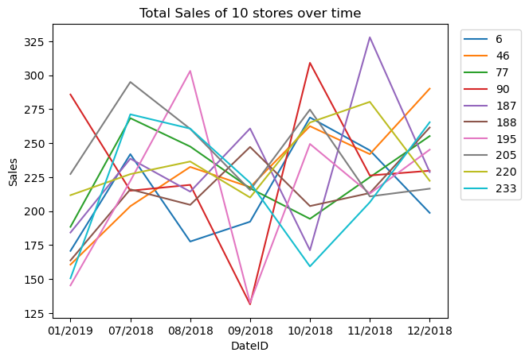

```python
plt.figure(figsize=(20, 5))
pivot_chips1.plot()
plt.title("Total Sales of 10 stores over time")
plt.legend(loc='upper right', bbox_to_anchor=(1.20, 1))
plt.xlabel("DateID")
plt.ylabel("Sales")
plt.show()
```

By observing the shape of the lines, we can see that the light blue line (store 233) could be a match with the green line (store 77), but we also need to take the correlations between them into consideration

```python
# Correlation
pivot_chips1.corr(method='pearson')
```

| STORE_NBR | 6 | 46 | 77 | 90 | 187 | 188 | 195 | 205 | 220 | 233 |
| --- | --- | --- | --- | --- | --- | --- | --- | --- | --- | --- |
| 6 | 1.000000 | 0.386333 | 0.002087 | 0.303803 | 0.162052 | 0.075145 | 0.232361 | 0.425296 | 0.738602 | -0.132245 |
| 46 | 0.386333 | 1.000000 | 0.309804 | 0.015970 | 0.130430 | 0.691737 | 0.585019 | -0.100303 | 0.428668 | 0.331100 |
| 77 | 0.002087 | 0.309804 | 1.000000 | -0.439456 | 0.329609 | 0.542511 | 0.488218 | 0.273728 | -0.118852 | 0.973643 |
| 90 | 0.303803 | 0.015970 | -0.439456 | 1.000000 | -0.593589 | -0.630481 | 0.288469 | 0.305958 | 0.377988 | -0.580808 |
| 187 | 0.162052 | 0.130430 | 0.329609 | -0.593589 | 1.000000 | 0.395246 | -0.156977 | -0.469238 | 0.340224 | 0.332260 |
| 188 | 0.075145 | 0.691737 | 0.542511 | -0.630481 | 0.395246 | 1.000000 | 0.089547 | -0.272592 | -0.126062 | 0.633106 |
| 195 | 0.232361 | 0.585019 | 0.488218 | 0.288469 | -0.156977 | 0.089547 | 1.000000 | 0.466917 | 0.445143 | 0.446483 |
| 205 | 0.425296 | -0.100303 | 0.273728 | 0.305958 | -0.469238 | -0.272592 | 0.466917 | 1.000000 | 0.093419 | 0.173432 |
| 220 | 0.738602 | 0.428668 | -0.118852 | 0.377988 | 0.340224 | -0.126062 | 0.445143 | 0.093419 | 1.000000 | -0.217204 |
| 233 | -0.132245 | 0.331100 | 0.973643 | -0.580808 | 0.332260 | 0.633106 | 0.446483 | 0.173432 | -0.217204 | 1.000000 |

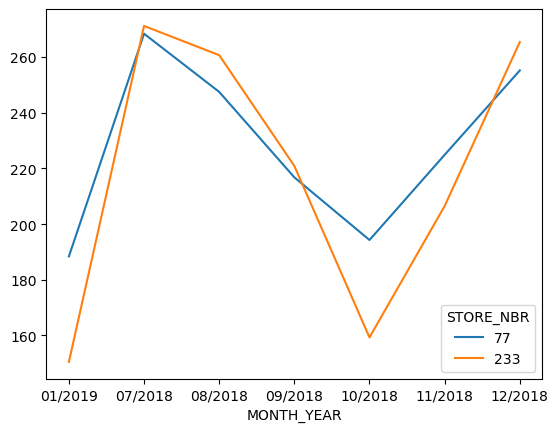

```python
# As expected, store 233 is the strongest correlation at 0.97. Let's graph it

chips1_graph = pivot_chips1[[77,233]]
chips1_graph.plot()
plt.show()
```

**For trial store 77, we will use store number 233 for a control store. It's a 0.97 correlation and only 61 dollars difference between the stores**

| **Trial** | **Total Sales** | **Control** | **Total Sales** |  |  |  |  |  |  |
| --- | --- | --- | --- | --- | --- | --- | --- | --- | --- |
| Store 77 | 1595.50 | Store 233 | 1534.50 |  |  |  |  |  |  |
| Store 86 | 5795.65 |  |  |  |  |  |  |  |  |
| Store 88 | 8832.80 |  |  |  |  |  |  |  |  |

```python
#Looking for control store to match with store 86

# Sorting stores by total sales lookig for a match for store 86 (total sales ~ 5795.65)
total_sorted['SALES_DIFF_86']=total_sorted['TOT_SALES']-5795.65
total_sorted['SALES_DIFF_86']=total_sorted['SALES_DIFF_86'].abs()
total_sorted[total_sorted['SALES_DIFF_86']<=150].sort_values(by='SALES_DIFF_86',ascending=True)
```

| STORE_NBR | TOT_SALES | NUM_CUS | TXN_PER_CUS | SALES_DIFF_77 | SALES_DIFF_86 |
| --- | --- | --- | --- | --- | --- |
| 86 | 5795.65 | 668 | 8.672105 | 4200.15 | 0.00 |
| 97 | 5793.35 | 668 | 8.756528 | 4197.85 | 2.30 |
| 91 | 5806.70 | 605 | 7.892081 | 4211.20 | 11.05 |
| 180 | 5784.40 | 661 | 8.809130 | 4188.90 | 11.25 |
| 109 | 5783.90 | 657 | 8.784393 | 4188.40 | 11.75 |
| 138 | 5811.90 | 672 | 8.683952 | 4216.40 | 16.25 |
| 227 | 5821.00 | 661 | 8.703543 | 4225.50 | 25.35 |
| 164 | 5767.70 | 658 | 8.794742 | 4172.20 | 27.95 |
| 62 | 5828.80 | 660 | 8.781560 | 4233.30 | 33.15 |
| 32 | 5754.40 | 632 | 8.919634 | 4158.90 | 41.25 |
| 102 | 5840.60 | 661 | 8.693723 | 4245.10 | 44.95 |
| 30 | 5747.10 | 646 | 8.645077 | 4151.60 | 48.55 |
| 207 | 5735.40 | 658 | 8.704411 | 4139.90 | 60.25 |
| 10 | 5859.95 | 669 | 8.614860 | 4264.45 | 64.30 |
| 105 | 5729.10 | 661 | 8.761597 | 4133.60 | 66.55 |
| 116 | 5717.50 | 663 | 8.717676 | 4122.00 | 78.15 |
| 48 | 5707.40 | 630 | 8.862497 | 4111.90 | 88.25 |
| 236 | 5694.80 | 634 | 8.890428 | 4099.30 | 100.85 |
| 221 | 5907.00 | 682 | 8.072461 | 4311.50 | 111.35 |
| 57 | 5679.10 | 662 | 8.508115 | 4083.60 | 116.55 |
| 13 | 5670.10 | 660 | 8.683220 | 4074.60 | 125.55 |
| 160 | 5928.10 | 681 | 8.582439 | 4332.60 | 132.45 |
| 104 | 5651.70 | 636 | 8.887029 | 4056.20 | 143.95 |
| 172 | 5649.40 | 625 | 9.057726 | 4053.90 | 146.25 |

```python
## Isolating the 10 stores
store_control_two = [97,91,180,109,138,227,164,62,32]
control_store2 = pd.concat([pre_trial[pre_trial['STORE_NBR']==97],pre_trial[pre_trial['STORE_NBR']==91],pre_trial[pre_trial['STORE_NBR']==180],pre_trial[pre_trial['STORE_NBR']==109],pre_trial[pre_trial['STORE_NBR']==138],pre_trial[pre_trial['STORE_NBR']==227],pre_trial[pre_trial['STORE_NBR']==164],pre_trial[pre_trial['STORE_NBR']==62],pre_trial[pre_trial['STORE_NBR']==32],pre_trial[pre_trial['STORE_NBR']==86]],join='outer',axis=0)
control_store2=control_store2[['STORE_NBR','MONTH_YEAR','TOT_SALES']]
control_store2=control_store2.groupby(['STORE_NBR','MONTH_YEAR'])[['TOT_SALES']].sum()
control_store2
```

| STORE_NBR | MONTH_YEAR | TOT_SALES |
| --- | --- | --- |
| 32 | 01/2019 | 756.6 |
|  | 07/2018 | 737.4 |
|  | 08/2018 | 719.0 |
|  | 09/2018 | 752.4 |
|  | 10/2018 | 951.4 |
| ... | ... | ... |
| 227 | 08/2018 | 810.8 |
|  | 09/2018 | 716.4 |
|  | 10/2018 | 954.4 |
|  | 11/2018 | 826.8 |
|  | 12/2018 | 772.6 |

70 rows × 1 columns

```python
# Putting the 10 in a pivot chart format
pivot_chips2=control_store2.pivot_table(index='MONTH_YEAR',columns='STORE_NBR',values='TOT_SALES')
pivot_chips2
```

| STORE_NBR MONTH_YEAR | 32 | 62 | 86 | 91 | 97 | 109 | 138 | 164 | 180 | 227 |
| --- | --- | --- | --- | --- | --- | --- | --- | --- | --- | --- |
| 01/2019 | 756.6 | 811.8 | 800.60 | 774.7 | 797.00 | 804.2 | 880.0 | 886.2 | 1004.2 | 900.6 |
| 07/2018 | 737.4 | 952.8 | 851.00 | 807.3 | 805.80 | 820.4 | 778.2 | 770.0 | 764.2 | 839.4 |
| 08/2018 | 719.0 | 745.6 | 726.85 | 819.2 | 865.55 | 801.3 | 660.3 | 859.7 | 721.4 | 810.8 |
| 09/2018 | 752.4 | 876.4 | 855.00 | 938.9 | 842.40 | 769.4 | 869.8 | 752.4 | 820.4 | 716.4 |
| 10/2018 | 951.4 | 764.0 | 898.80 | 795.7 | 926.60 | 868.8 | 910.8 | 788.2 | 793.4 | 954.4 |
| 11/2018 | 958.6 | 856.4 | 851.20 | 865.3 | 761.60 | 884.6 | 906.4 | 729.8 | 748.8 | 826.8 |
| 12/2018 | 879.0 | 821.8 | 812.20 | 805.6 | 794.40 | 835.2 | 806.4 | 981.4 | 932.0 | 772.6 |

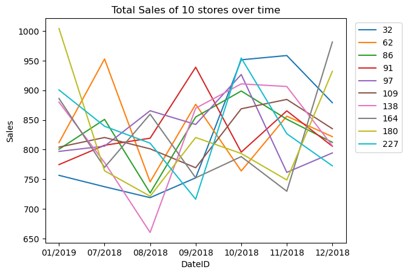

```python
plt.figure(figsize=(20, 5))
pivot_chips2.plot()
plt.title("Total Sales of 10 stores over time")
plt.legend(loc='upper right', bbox_to_anchor=(1.20, 1))
plt.xlabel("DateID")
plt.ylabel("Sales")
plt.show()
```

```python
pivot_chips2.corr(method='pearson')
```

| STORE_NBR | 32 | 62 | 86 | 91 | 97 | 109 | 138 | 164 | 180 | 227 |
| --- | --- | --- | --- | --- | --- | --- | --- | --- | --- | --- |
| 32 | 1.000000 | -0.206908 | 0.576268 | -0.055531 | 0.023346 | 0.891766 | 0.627391 | -0.119695 | -0.061139 | 0.341860 |
| 62 | -0.206908 | 1.000000 | 0.396342 | 0.322834 | -0.541255 | -0.129148 | 0.151928 | -0.409961 | -0.068908 | -0.350127 |
| 86 | 0.576268 | 0.396342 | 1.000000 | 0.207730 | 0.159505 | 0.430281 | 0.796065 | -0.532798 | -0.048221 | 0.262709 |
| 91 | -0.055531 | 0.322834 | 0.207730 | 1.000000 | -0.082746 | -0.312514 | 0.169317 | -0.546527 | -0.349533 | -0.733593 |
| 97 | 0.023346 | -0.541255 | 0.159505 | -0.082746 | 1.000000 | -0.069234 | -0.084245 | -0.100467 | -0.284620 | 0.370271 |
| 109 | 0.891766 | -0.129148 | 0.430281 | -0.312514 | -0.069234 | 1.000000 | 0.409013 | -0.161655 | -0.223012 | 0.523559 |
| 138 | 0.627391 | 0.151928 | 0.796065 | 0.169317 | -0.084245 | 0.409013 | 1.000000 | -0.347917 | 0.331896 | 0.305025 |
| 164 | -0.119695 | -0.409961 | -0.532798 | -0.546527 | -0.100467 | -0.161655 | -0.347917 | 1.000000 | 0.648488 | -0.043883 |
| 180 | -0.061139 | -0.068908 | -0.048221 | -0.349533 | -0.284620 | -0.223012 | 0.331896 | 0.648488 | 1.000000 | 0.096818 |
| 227 | 0.341860 | -0.350127 | 0.262709 | -0.733593 | 0.370271 | 0.523559 | 0.305025 | -0.043883 | 0.096818 | 1.000000 |

Based on the shape of the line graph, we can see that pink line (store 138) is the only one that has the most similar pattern to store 86 (green line) even though it doesn't match perfectly. Running the correlation test shows the strongest store is 0.79 which is store 138

Even though these 9 stores are the best fit with total sales, it's not the best fit when it comes to sales pattern over the months. We will further explore for a better option

We want to keep it as close as possible to the total sales of 5795.65. We will grab the next 10 above by total sales

```python
total_sorted[total_sorted['SALES_DIFF_86']<=150].sort_values(by='SALES_DIFF_86',ascending=True)
```

| STORE_NBR | TOT_SALES | NUM_CUS | TXN_PER_CUS | SALES_DIFF_77 | SALES_DIFF_86 |
| --- | --- | --- | --- | --- | --- |
| 86 | 5795.65 | 668 | 8.672105 | 4200.15 | 0.00 |
| 97 | 5793.35 | 668 | 8.756528 | 4197.85 | 2.30 |
| 91 | 5806.70 | 605 | 7.892081 | 4211.20 | 11.05 |
| 180 | 5784.40 | 661 | 8.809130 | 4188.90 | 11.25 |
| 109 | 5783.90 | 657 | 8.784393 | 4188.40 | 11.75 |
| 138 | 5811.90 | 672 | 8.683952 | 4216.40 | 16.25 |
| 227 | 5821.00 | 661 | 8.703543 | 4225.50 | 25.35 |
| 164 | 5767.70 | 658 | 8.794742 | 4172.20 | 27.95 |
| 62 | 5828.80 | 660 | 8.781560 | 4233.30 | 33.15 |
| 32 | 5754.40 | 632 | 8.919634 | 4158.90 | 41.25 |
| 102 | 5840.60 | 661 | 8.693723 | 4245.10 | 44.95 |
| 30 | 5747.10 | 646 | 8.645077 | 4151.60 | 48.55 |
| 207 | 5735.40 | 658 | 8.704411 | 4139.90 | 60.25 |
| 10 | 5859.95 | 669 | 8.614860 | 4264.45 | 64.30 |
| 105 | 5729.10 | 661 | 8.761597 | 4133.60 | 66.55 |
| 116 | 5717.50 | 663 | 8.717676 | 4122.00 | 78.15 |
| 48 | 5707.40 | 630 | 8.862497 | 4111.90 | 88.25 |
| 236 | 5694.80 | 634 | 8.890428 | 4099.30 | 100.85 |
| 221 | 5907.00 | 682 | 8.072461 | 4311.50 | 111.35 |
| 57 | 5679.10 | 662 | 8.508115 | 4083.60 | 116.55 |
| 13 | 5670.10 | 660 | 8.683220 | 4074.60 | 125.55 |
| 160 | 5928.10 | 681 | 8.582439 | 4332.60 | 132.45 |
| 104 | 5651.70 | 636 | 8.887029 | 4056.20 | 143.95 |
| 172 | 5649.40 | 625 | 9.057726 | 4053.90 | 146.25 |

```python
# The next 10 above by total sales
stores_control_three = [102, 30, 207, 10, 105,116,48,236,221,57]

control_store3 = pd.concat([pre_trial[pre_trial['STORE_NBR']==102],pre_trial[pre_trial['STORE_NBR']==30],pre_trial[pre_trial['STORE_NBR']==207],pre_trial[pre_trial['STORE_NBR']==10],pre_trial[pre_trial['STORE_NBR']==105],pre_trial[pre_trial['STORE_NBR']==116],pre_trial[pre_trial['STORE_NBR']==48],pre_trial[pre_trial['STORE_NBR']==236],pre_trial[pre_trial['STORE_NBR']==221],pre_trial[pre_trial['STORE_NBR']==86],pre_trial[pre_trial['STORE_NBR']==57]],join='outer',axis=0)
control_store3=control_store3[['STORE_NBR','MONTH_YEAR','TOT_SALES']]
control_store3=control_store3.groupby(['STORE_NBR','MONTH_YEAR'])[['TOT_SALES']].sum()
control_store3
```

| STORE_NBR | MONTH_YEAR | TOT_SALES |
| --- | --- | --- |
| 10 | 01/2019 | 791.20 |
|  | 07/2018 | 829.20 |
|  | 08/2018 | 857.75 |
|  | 09/2018 | 888.00 |
|  | 10/2018 | 812.00 |
| ... | ... | ... |
| 236 | 08/2018 | 906.00 |
|  | 09/2018 | 800.80 |
|  | 10/2018 | 781.20 |
|  | 11/2018 | 647.80 |
|  | 12/2018 | 875.20 |

77 rows × 1 columns

```python
# Putting the 10 in a pivot chart format
pivot_chips3=control_store3.pivot_table(index='MONTH_YEAR',columns='STORE_NBR',values='TOT_SALES')
pivot_chips3
```

| STORE_NBR MONTH_YEAR | 10 | 30 | 48 | 57 | 86 | 102 | 105 | 116 | 207 | 221 | 236 |
| --- | --- | --- | --- | --- | --- | --- | --- | --- | --- | --- | --- |
| 01/2019 | 791.20 | 755.8 | 836.2 | 747.4 | 800.60 | 865.8 | 736.4 | 816.6 | 793.0 | 846.1 | 798.4 |
| 07/2018 | 829.20 | 827.8 | 871.4 | 768.8 | 851.00 | 746.4 | 859.5 | 814.2 | 870.4 | 915.5 | 885.4 |
| 08/2018 | 857.75 | 873.9 | 828.6 | 873.9 | 726.85 | 923.2 | 860.8 | 778.7 | 781.6 | 880.7 | 906.0 |
| 09/2018 | 888.00 | 793.0 | 759.8 | 742.4 | 855.00 | 898.4 | 792.0 | 847.4 | 731.6 | 686.8 | 800.8 |
| 10/2018 | 812.00 | 798.0 | 807.4 | 870.2 | 898.80 | 795.8 | 806.6 | 819.8 | 881.6 | 825.2 | 781.2 |
| 11/2018 | 787.80 | 779.8 | 744.4 | 779.6 | 851.20 | 847.2 | 711.2 | 779.8 | 903.0 | 879.2 | 647.8 |
| 12/2018 | 894.00 | 918.8 | 859.6 | 896.8 | 812.20 | 763.8 | 962.6 | 861.0 | 774.2 | 873.5 | 875.2 |

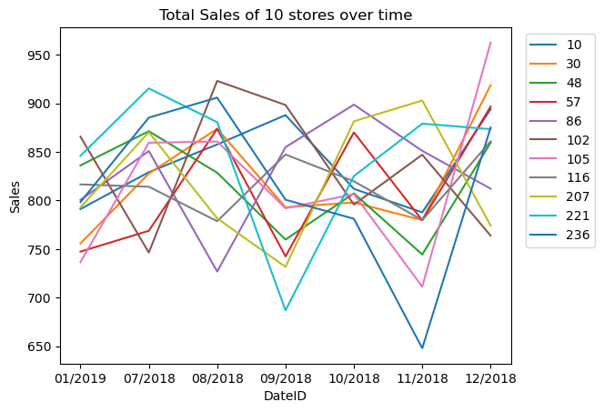

```python
plt.figure(figsize=(20, 5))
pivot_chips3.plot()
plt.title("Total Sales of 10 stores over time")
plt.legend(loc='upper right', bbox_to_anchor=(1.20, 1))
plt.xlabel("DateID")
plt.ylabel("Sales")
plt.show()
```

```python
pivot_chips3.corr(method='pearson')
```

| STORE_NBR | 10 | 30 | 48 | 57 | 86 | 102 | 105 | 116 | 207 | 221 | 236 |
| --- | --- | --- | --- | --- | --- | --- | --- | --- | --- | --- | --- |
| 10 | 1.000000 | 0.717176 | 0.179039 | 0.345194 | -0.240262 | 0.037576 | 0.751159 | 0.624481 | -0.744240 | -0.381062 | 0.601101 |
| 30 | 0.717176 | 1.000000 | 0.526979 | 0.765790 | -0.440247 | -0.270942 | 0.938451 | 0.273356 | -0.303189 | 0.332755 | 0.672642 |
| 48 | 0.179039 | 0.526979 | 1.000000 | 0.340138 | -0.317739 | -0.532593 | 0.680746 | 0.246943 | -0.092821 | 0.565622 | 0.802886 |
| 57 | 0.345194 | 0.765790 | 0.340138 | 1.000000 | -0.244746 | -0.217317 | 0.680749 | 0.061767 | 0.013605 | 0.344508 | 0.377498 |
| 86 | -0.240262 | -0.440247 | -0.317739 | -0.244746 | 1.000000 | -0.515874 | -0.265034 | 0.322837 | 0.486758 | -0.298372 | -0.509266 |
| 102 | 0.037576 | -0.270942 | -0.532593 | -0.217317 | -0.515874 | 1.000000 | -0.441916 | -0.392525 | -0.472293 | -0.459407 | -0.129950 |
| 105 | 0.751159 | 0.938451 | 0.680746 | 0.680749 | -0.265034 | -0.441916 | 1.000000 | 0.494583 | -0.339151 | 0.240315 | 0.791335 |
| 116 | 0.624481 | 0.273356 | 0.246943 | 0.061767 | 0.322837 | -0.392525 | 0.494583 | 1.000000 | -0.521225 | -0.464720 | 0.286081 |
| 207 | -0.744240 | -0.303189 | -0.092821 | 0.013605 | 0.486758 | -0.472293 | -0.339151 | -0.521225 | 1.000000 | 0.563338 | -0.494713 |
| 221 | -0.381062 | 0.332755 | 0.565622 | 0.344508 | -0.298372 | -0.459407 | 0.240315 | -0.464720 | 0.563338 | 1.000000 | 0.179549 |
| 236 | 0.601101 | 0.672642 | 0.802886 | 0.377498 | -0.509266 | -0.129950 | 0.791335 | 0.286081 | -0.494713 | 0.179549 | 1.000000 |

We are still not sastified with the line graph and correlation test results as there is no store that has similar total sales pattern and stronger correlation with store 86. We will pick the next 10 stores

```python
total_sorted[total_sorted['SALES_DIFF_86']<=200].sort_values(by='SALES_DIFF_86',ascending=True)
```

| STORE_NBR | TOT_SALES | NUM_CUS | TXN_PER_CUS | SALES_DIFF_77 | SALES_DIFF_86 |
| --- | --- | --- | --- | --- | --- |
| 86 | 5795.65 | 668 | 8.672105 | 4200.15 | 0.00 |
| 97 | 5793.35 | 668 | 8.756528 | 4197.85 | 2.30 |
| 91 | 5806.70 | 605 | 7.892081 | 4211.20 | 11.05 |
| 180 | 5784.40 | 661 | 8.809130 | 4188.90 | 11.25 |
| 109 | 5783.90 | 657 | 8.784393 | 4188.40 | 11.75 |
| 138 | 5811.90 | 672 | 8.683952 | 4216.40 | 16.25 |
| 227 | 5821.00 | 661 | 8.703543 | 4225.50 | 25.35 |
| 164 | 5767.70 | 658 | 8.794742 | 4172.20 | 27.95 |
| 62 | 5828.80 | 660 | 8.781560 | 4233.30 | 33.15 |
| 32 | 5754.40 | 632 | 8.919634 | 4158.90 | 41.25 |
| 102 | 5840.60 | 661 | 8.693723 | 4245.10 | 44.95 |
| 30 | 5747.10 | 646 | 8.645077 | 4151.60 | 48.55 |
| 207 | 5735.40 | 658 | 8.704411 | 4139.90 | 60.25 |
| 10 | 5859.95 | 669 | 8.614860 | 4264.45 | 64.30 |
| 105 | 5729.10 | 661 | 8.761597 | 4133.60 | 66.55 |
| 116 | 5717.50 | 663 | 8.717676 | 4122.00 | 78.15 |
| 48 | 5707.40 | 630 | 8.862497 | 4111.90 | 88.25 |
| 236 | 5694.80 | 634 | 8.890428 | 4099.30 | 100.85 |
| 221 | 5907.00 | 682 | 8.072461 | 4311.50 | 111.35 |
| 57 | 5679.10 | 662 | 8.508115 | 4083.60 | 116.55 |
| 13 | 5670.10 | 660 | 8.683220 | 4074.60 | 125.55 |
| 160 | 5928.10 | 681 | 8.582439 | 4332.60 | 132.45 |
| 104 | 5651.70 | 636 | 8.887029 | 4056.20 | 143.95 |
| 172 | 5649.40 | 625 | 9.057726 | 4053.90 | 146.25 |
| 39 | 5643.70 | 645 | 8.742371 | 4048.20 | 151.95 |
| 232 | 5949.10 | 675 | 8.656982 | 4353.60 | 153.45 |
| 184 | 5956.50 | 653 | 9.005595 | 4361.00 | 160.85 |
| 122 | 5631.60 | 651 | 8.642736 | 4036.10 | 164.05 |
| 257 | 5961.90 | 692 | 8.631157 | 4366.40 | 166.25 |
| 155 | 5962.30 | 666 | 8.844933 | 4366.80 | 166.65 |
| 196 | 5616.90 | 646 | 8.620679 | 4021.40 | 178.75 |
| 67 | 5601.20 | 658 | 8.404751 | 4005.70 | 194.45 |

```python
# The next 10 above by total sales
stores_control_four = [13, 160, 104, 172, 39,232,184,122,257,155]

control_store4 = pd.concat([pre_trial[pre_trial['STORE_NBR']==13],pre_trial[pre_trial['STORE_NBR']==160],pre_trial[pre_trial['STORE_NBR']==104],pre_trial[pre_trial['STORE_NBR']==172],pre_trial[pre_trial['STORE_NBR']==39],pre_trial[pre_trial['STORE_NBR']==232],pre_trial[pre_trial['STORE_NBR']==184],pre_trial[pre_trial['STORE_NBR']==122],pre_trial[pre_trial['STORE_NBR']==257],pre_trial[pre_trial['STORE_NBR']==86],pre_trial[pre_trial['STORE_NBR']==155]],join='outer',axis=0)
control_store4=control_store4[['STORE_NBR','MONTH_YEAR','TOT_SALES']]
control_store4=control_store4.groupby(['STORE_NBR','MONTH_YEAR'])[['TOT_SALES']].sum()
control_store4
```

| STORE_NBR | MONTH_YEAR | TOT_SALES |
| --- | --- | --- |
| 13 | 01/2019 | 836.4 |
|  | 07/2018 | 754.6 |
|  | 08/2018 | 709.1 |
|  | 09/2018 | 794.8 |
|  | 10/2018 | 773.6 |
| ... | ... | ... |
| 257 | 08/2018 | 850.3 |
|  | 09/2018 | 887.4 |
|  | 10/2018 | 693.6 |
|  | 11/2018 | 1026.6 |
|  | 12/2018 | 812.0 |

77 rows × 1 columns

```python
# Putting the 10 in a pivot chart format
pivot_chips4=control_store4.pivot_table(index='MONTH_YEAR',columns='STORE_NBR',values='TOT_SALES')
pivot_chips4
```

| STORE_NBR MONTH_YEAR | 13 | 39 | 86 | 104 | 122 | 155 | 160 | 172 | 184 | 232 | 257 |
| --- | --- | --- | --- | --- | --- | --- | --- | --- | --- | --- | --- |
| 01/2019 | 836.4 | 784.4 | 800.60 | 839.8 | 813.8 | 834.6 | 854.2 | 842.6 | 882.4 | 745.8 | 717.6 |
| 07/2018 | 754.6 | 807.8 | 851.00 | 777.8 | 832.4 | 900.6 | 826.0 | 738.4 | 889.2 | 947.9 | 974.4 |
| 08/2018 | 709.1 | 885.3 | 726.85 | 850.9 | 819.2 | 738.7 | 701.7 | 708.2 | 835.5 | 687.2 | 850.3 |
| 09/2018 | 794.8 | 789.4 | 855.00 | 749.4 | 831.0 | 939.6 | 852.0 | 767.2 | 820.4 | 885.4 | 887.4 |
| 10/2018 | 773.6 | 802.6 | 898.80 | 867.0 | 821.2 | 914.0 | 856.8 | 931.4 | 870.4 | 853.2 | 693.6 |
| 11/2018 | 960.0 | 800.0 | 851.20 | 715.0 | 710.0 | 835.0 | 899.0 | 811.4 | 832.4 | 892.0 | 1026.6 |
| 12/2018 | 841.6 | 774.2 | 812.20 | 851.8 | 804.0 | 799.8 | 938.4 | 850.2 | 826.2 | 937.6 | 812.0 |

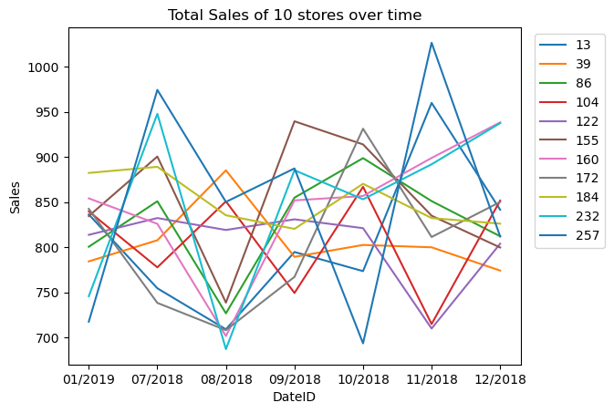

```python
plt.figure(figsize=(20, 5))
pivot_chips4.plot()
plt.title("Total Sales of 10 stores over time")
plt.legend(loc='upper right', bbox_to_anchor=(1.20, 1))
plt.xlabel("DateID")
plt.ylabel("Sales")
plt.show()
```

```python
pivot_chips4.corr(method='pearson')
```

| STORE_NBR | 13 | 39 | 86 | 104 | 122 | 155 | 160 | 172 | 184 | 232 | 257 |
| --- | --- | --- | --- | --- | --- | --- | --- | --- | --- | --- | --- |
| 13 | 1.000000 | -0.574159 | 0.309198 | -0.543311 | -0.868591 | 0.014386 | 0.734660 | 0.348344 | -0.254404 | 0.351473 | 0.334773 |
| 39 | -0.574159 | 1.000000 | -0.638403 | 0.198233 | 0.116761 | -0.540361 | -0.924015 | -0.590359 | -0.078339 | -0.653708 | 0.116305 |
| 86 | 0.309198 | -0.638403 | 1.000000 | -0.314667 | -0.098468 | 0.869532 | 0.600665 | 0.583414 | 0.221351 | 0.692945 | 0.026916 |
| 104 | -0.543311 | 0.198233 | -0.314667 | 1.000000 | 0.542022 | -0.358822 | -0.224259 | 0.372860 | 0.268994 | -0.434627 | -0.849644 |
| 122 | -0.868591 | 0.116761 | -0.098468 | 0.542022 | 1.000000 | 0.248657 | -0.385509 | -0.125473 | 0.326835 | -0.145077 | -0.506038 |
| 155 | 0.014386 | -0.540361 | 0.869532 | -0.358822 | 0.248657 | 1.000000 | 0.341222 | 0.283125 | 0.262143 | 0.553458 | 0.016777 |
| 160 | 0.734660 | -0.924015 | 0.600665 | -0.224259 | -0.385509 | 0.341222 | 1.000000 | 0.630219 | -0.119275 | 0.718784 | 0.013815 |
| 172 | 0.348344 | -0.590359 | 0.583414 | 0.372860 | -0.125473 | 0.283125 | 0.630219 | 1.000000 | 0.191151 | 0.192733 | -0.622949 |
| 184 | -0.254404 | -0.078339 | 0.221351 | 0.268994 | 0.326835 | 0.262143 | -0.119275 | 0.191151 | 1.000000 | -0.058174 | -0.278420 |
| 232 | 0.351473 | -0.653708 | 0.692945 | -0.434627 | -0.145077 | 0.553458 | 0.718784 | 0.192733 | -0.058174 | 1.000000 | 0.424682 |
| 257 | 0.334773 | 0.116305 | 0.026916 | -0.849644 | -0.506038 | 0.016777 | 0.013815 | -0.622949 | -0.278420 | 0.424682 | 1.000000 |

We can see that the brown line (store 155) has the most similar pattern to store 86 (green line), and the correlation test also shows 0.87 correlation, which is better than store 138. Let's have a better look at the pattern by graphing only store 86 and 155

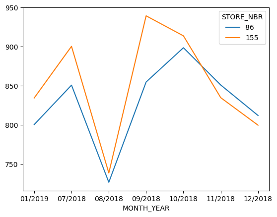

```python
chips2_graph = pivot_chips4[[86,155]]
chips2_graph.plot()
plt.show()
```

Based on the line graph, store 155 looks promising with a strong correlation of 0.87, but let's see how it looks compared to the top 10

```python
total_grp=pre_trial.groupby(['STORE_NBR','MONTH_YEAR'])[['TOT_SALES']].sum()
total_grp
```

| STORE_NBR | MONTH_YEAR | TOT_SALES |
| --- | --- | --- |
| 1 | 01/2019 | 149.70 |
|  | 07/2018 | 188.90 |
|  | 08/2018 | 168.40 |
|  | 09/2018 | 268.10 |
|  | 10/2018 | 175.40 |
| ... | ... | ... |
| 272 | 08/2018 | 326.95 |
|  | 09/2018 | 294.50 |
|  | 10/2018 | 405.10 |
|  | 11/2018 | 355.80 |
|  | 12/2018 | 363.10 |

1813 rows × 1 columns

```python
total_grp_pivot = total_grp.pivot_table(index='MONTH_YEAR', columns='STORE_NBR',values='TOT_SALES')
total_grp_pivot_corr = total_grp_pivot.corr(method='pearson')
```

[output not shown]

259 rows × 259 columns

```python
# Top 10 correlation with store 86
total_grp_pivot_corr[86].sort_values(ascending=False).head(10)
```

```
STORE_NBR
86     1.000000
155    0.869532
132    0.842632
260    0.827631
138    0.796065
6      0.781804
114    0.750924
269    0.747432
222    0.741962
56     0.735300
Name: 86, dtype: float64
```

These are the top 10 correlations to the store 86. Store 155 would be ranked in the 1st place. Let's look at other stores by total sales before we make a decision

```python
total_sorted.loc[[155,132,260,138]]
```

| STORE_NBR | TOT_SALES | NUM_CUS | TXN_PER_CUS | SALES_DIFF_77 | SALES_DIFF_86 |
| --- | --- | --- | --- | --- | --- |
| 155 | 5962.3 | 666 | 8.844933 | 4366.8 | 166.65 |
| 132 | 263.2 | 43 | 7.000000 | 1332.3 | 5532.45 |
| 260 | 2832.2 | 315 | 7.324282 | 1236.7 | 2963.45 |
| 138 | 5811.9 | 672 | 8.683952 | 4216.4 | 16.25 |

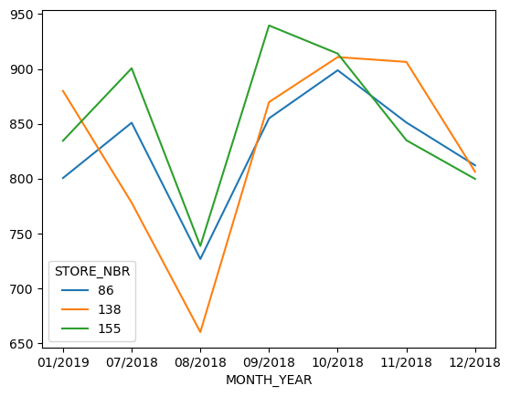

```python
#Store 132 and 260's sales are way too low compared to store 86, so we will remove from the potential list
potential_list = total_grp.loc[[86,155,138]]
#Pivoting the dataframe
potential_list_pivot=potential_list.pivot_table(index='MONTH_YEAR', columns='STORE_NBR',values='TOT_SALES')
#Plotting the pivot
potential_list_pivot.plot()
plt.show()
```

**Even though store 138 has a good correlation to store 86, store 155 is a much better fit. So we will choose store 155 as the control store for stpre 86**

| **Trial** | **Total Sales** | **Control** | **Total Sales** |
| --- | --- | --- | --- |
| Store 77 | 1595.50 | Store 233 | 1534.50 |
| Store 86 | 5795.65 | Store 155 | 5962.3 |
| Store 88 | 8832.80 |  |  |

```python
# Looking for control store for store 88
# Top 20 correlation with store 88
total_grp_pivot_corr[88].sort_values(ascending=False).head(20)
```

```
STORE_NBR
88     1.000000
159    0.938775
91     0.911986
204    0.871969
1      0.842232
240    0.817245
61     0.777007
79     0.771989
225    0.735724
163    0.713393
7      0.698846
182    0.695890
190    0.641662
106    0.614378
134    0.611121
161    0.574107
223    0.560700
99     0.546738
187    0.535091
145    0.511910
Name: 88, dtype: float64
```

```python
control_store5 = total_grp.loc[[88,159,91,204,1,240,61,79,225,163,7,182,190,106,134,161,223,99,187,145]]
control_store5.groupby(['STORE_NBR'])[['TOT_SALES']].sum()
```

| STORE_NBR | TOT_SALES |
| --- | --- |
| 1 | 1295.90 |
| 7 | 6925.90 |
| 61 | 322.90 |
| 79 | 6673.95 |
| 88 | 8832.80 |
| 91 | 5806.70 |
| 99 | 103.30 |
| 106 | 6138.95 |
| 134 | 2865.55 |
| 145 | 2102.60 |
| 159 | 167.20 |
| 161 | 216.40 |
| 163 | 1427.80 |
| 182 | 2588.30 |
| 187 | 1625.70 |
| 190 | 5291.30 |
| 204 | 266.90 |
| 223 | 6253.70 |
| 225 | 5551.60 |
| 240 | 2606.50 |

```python
# Sorting stores by total sales lookig for a match for store 88 (total sales ~ 8832.80)
total_sorted['SALES_DIFF_88']=total_sorted['TOT_SALES']-8832.80
total_sorted['SALES_DIFF_88']=total_sorted['SALES_DIFF_88'].abs()
total_sorted[total_sorted['SALES_DIFF_88']<=1000].sort_values(by='SALES_DIFF_88',ascending=True)
```

| STORE_NBR | TOT_SALES | NUM_CUS | TXN_PER_CUS | SALES_DIFF_77 | SALES_DIFF_86 | SALES_DIFF_88 |
| --- | --- | --- | --- | --- | --- | --- |
| 88 | 8832.80 | 848 | 8.404664 | 7237.30 | 3037.15 | 0.00 |
| 237 | 8915.10 | 852 | 8.389821 | 7319.60 | 3119.45 | 82.30 |
| 165 | 8748.20 | 827 | 8.371690 | 7152.70 | 2952.55 | 84.60 |
| 58 | 8576.95 | 832 | 8.267730 | 6981.45 | 2781.30 | 255.85 |
| 4 | 8576.20 | 811 | 8.483620 | 6980.70 | 2780.55 | 256.60 |
| 203 | 8301.10 | 796 | 8.321097 | 6705.60 | 2505.45 | 531.70 |
| 40 | 8224.20 | 816 | 8.041069 | 6628.70 | 2428.55 | 608.60 |
| 199 | 8200.50 | 795 | 8.221691 | 6605.00 | 2404.85 | 632.30 |
| 226 | 9657.75 | 915 | 8.532510 | 8062.25 | 3862.10 | 824.95 |
| 26 | 7958.50 | 780 | 8.130354 | 6363.00 | 2162.85 | 874.30 |
| 181 | 7912.85 | 783 | 8.230101 | 6317.35 | 2117.20 | 919.95 |
| 72 | 7875.90 | 762 | 8.298691 | 6280.40 | 2080.25 | 956.90 |
| 217 | 7872.70 | 738 | 8.447750 | 6277.20 | 2077.05 | 960.10 |

```python
store_control_five = [237,165,58,4,203,40,199,266,26,181,72,217]

control_store5 = total_grp.loc[[237,165,58,4,203,40,199,266,26,181,72,217,88]]
control_store5=control_store5.groupby(['STORE_NBR','MONTH_YEAR'])[['TOT_SALES']].sum()
control_store5
```

| STORE_NBR | MONTH_YEAR | TOT_SALES |
| --- | --- | --- |
| 4 | 01/2019 | 1402.6 |
|  | 07/2018 | 1318.3 |
|  | 08/2018 | 1188.1 |
|  | 09/2018 | 1168.0 |
|  | 10/2018 | 1275.0 |
| ... | ... | ... |
| 266 | 08/2018 | 135.0 |
|  | 09/2018 | 133.4 |
|  | 10/2018 | 162.7 |
|  | 11/2018 | 124.7 |
|  | 12/2018 | 150.1 |

91 rows × 1 columns

```python
# Putting the 10 in a pivot chart format
pivot_chips5=control_store5.pivot_table(index='MONTH_YEAR',columns='STORE_NBR',values='TOT_SALES')
pivot_chips5
```

| STORE_NBR MONTH_YEAR | 4 | 26 | 40 | 58 | 72 | 88 | 165 | 181 | 199 | 203 | 217 | 237 | 266 |
| --- | --- | --- | --- | --- | --- | --- | --- | --- | --- | --- | --- | --- | --- |
| 01/2019 | 1402.6 | 1123.0 | 1195.2 | 1195.00 | 1111.8 | 1215.4 | 1360.8 | 1092.70 | 1163.4 | 1105.2 | 1079.2 | 1117.7 | 129.1 |
| 07/2018 | 1318.3 | 1214.4 | 1230.0 | 1515.00 | 1252.2 | 1218.2 | 1406.0 | 1303.40 | 1238.4 | 1215.8 | 1278.8 | 1387.2 | 124.7 |
| 08/2018 | 1188.1 | 965.3 | 1126.4 | 962.15 | 1141.7 | 1242.2 | 1145.4 | 984.65 | 1169.3 | 1114.8 | 1022.1 | 1321.9 | 135.0 |
| 09/2018 | 1168.0 | 1211.8 | 1261.0 | 1338.40 | 1131.8 | 1361.8 | 1250.6 | 1073.60 | 1082.6 | 1185.2 | 1237.0 | 1250.8 | 133.4 |
| 10/2018 | 1275.0 | 1062.6 | 1201.2 | 1348.40 | 1163.4 | 1270.8 | 1183.4 | 1208.30 | 1201.4 | 1210.9 | 1032.8 | 1287.1 | 162.7 |
| 11/2018 | 1089.6 | 1166.4 | 997.4 | 1073.20 | 987.6 | 1311.4 | 1209.6 | 1101.20 | 1070.2 | 1193.8 | 1189.8 | 1316.0 | 124.7 |
| 12/2018 | 1134.6 | 1215.0 | 1213.0 | 1144.80 | 1087.4 | 1213.0 | 1192.4 | 1149.00 | 1275.2 | 1275.4 | 1033.0 | 1234.4 | 150.1 |

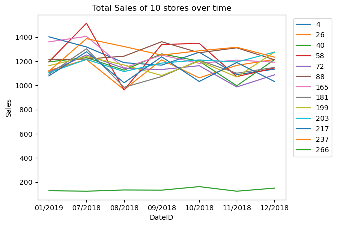

```python
plt.figure(figsize=(20, 5))
pivot_chips5.plot()
plt.title("Total Sales of 10 stores over time")
plt.legend(loc='upper right', bbox_to_anchor=(1.20, 1))
plt.xlabel("DateID")
plt.ylabel("Sales")
plt.show()
```

```python
pivot_chips5.corr(method='pearson')
```

| STORE_NBR | 4 | 26 | 40 | 58 | 72 | 88 | 165 | 181 | 199 | 203 | 217 | 237 | 266 |
| --- | --- | --- | --- | --- | --- | --- | --- | --- | --- | --- | --- | --- | --- |
| 4 | 1.000000 | -0.126093 | 0.467968 | 0.471380 | 0.608801 | -0.506130 | 0.700157 | 0.354931 | 0.313403 | -0.424690 | -0.019995 | -0.336545 | -0.053390 |
| 26 | -0.126093 | 1.000000 | 0.289814 | 0.530493 | -0.047472 | 0.158180 | 0.502574 | 0.506465 | 0.044337 | 0.621314 | 0.654837 | -0.037994 | -0.249970 |
| 40 | 0.467968 | 0.289814 | 1.000000 | 0.652823 | 0.718131 | -0.139776 | 0.371582 | 0.347337 | 0.465831 | 0.192524 | 0.082842 | -0.218527 | 0.305892 |
| 58 | 0.471380 | 0.530493 | 0.652823 | 1.000000 | 0.690379 | 0.042724 | 0.655980 | 0.828402 | 0.244983 | 0.364742 | 0.590411 | 0.215674 | 0.048359 |
| 72 | 0.608801 | -0.047472 | 0.718131 | 0.690379 | 1.000000 | -0.337773 | 0.465879 | 0.527669 | 0.526702 | 0.006513 | 0.197064 | 0.325561 | 0.097499 |
| 88 | -0.506130 | 0.158180 | -0.139776 | 0.042724 | -0.337773 | 1.000000 | -0.289887 | -0.293910 | -0.822121 | 0.000674 | 0.421174 | 0.109878 | -0.089942 |
| 165 | 0.700157 | 0.502574 | 0.371582 | 0.655980 | 0.465879 | -0.289887 | 1.000000 | 0.549644 | 0.132120 | -0.114660 | 0.610726 | -0.099816 | -0.548009 |
| 181 | 0.354931 | 0.506465 | 0.347337 | 0.828402 | 0.527669 | -0.293910 | 0.549644 | 1.000000 | 0.525488 | 0.602118 | 0.393892 | 0.359885 | 0.145207 |
| 199 | 0.313403 | 0.044337 | 0.465831 | 0.244983 | 0.526702 | -0.822121 | 0.132120 | 0.525488 | 1.000000 | 0.448794 | -0.365515 | 0.073052 | 0.454982 |
| 203 | -0.424690 | 0.621314 | 0.192524 | 0.364742 | 0.006513 | 0.000674 | -0.114660 | 0.602118 | 0.448794 | 1.000000 | 0.142998 | 0.320209 | 0.420709 |
| 217 | -0.019995 | 0.654837 | 0.082842 | 0.590411 | 0.197064 | 0.421174 | 0.610726 | 0.393892 | -0.365515 | 0.142998 | 1.000000 | 0.401760 | -0.661374 |
| 237 | -0.336545 | -0.037994 | -0.218527 | 0.215674 | 0.325561 | 0.109878 | -0.099816 | 0.359885 | 0.073052 | 0.320209 | 0.401760 | 1.000000 | -0.119374 |
| 266 | -0.053390 | -0.249970 | 0.305892 | 0.048359 | 0.097499 | -0.089942 | -0.548009 | 0.145207 | 0.454982 | 0.420709 | -0.661374 | -0.119374 | 1.000000 |

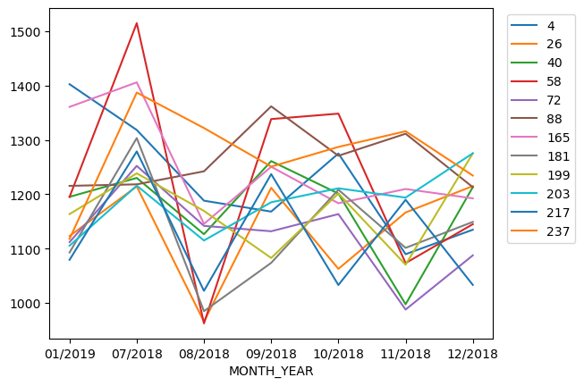

```python
#removing store 266 to have a better look
control_store6=control_store5.loc[[237,165,58,4,203,40,199,26,181,72,217,88]]

pivot_chips6=control_store6.pivot_table(index='MONTH_YEAR',columns='STORE_NBR',values='TOT_SALES')
plt.figure(figsize=(20,5))
pivot_chips6.plot()
plt.legend(loc='upper right', bbox_to_anchor=(1.20, 1))
plt.show()
```

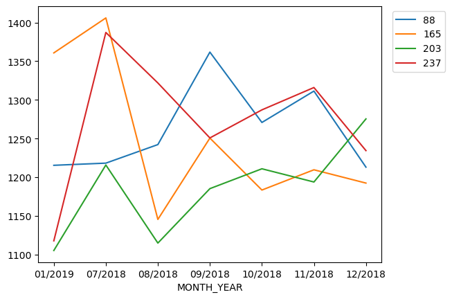

```python
#removing store 40, 72, 26, 4, 199, 217, 58, 181 to have a better look
control_store7=control_store5.loc[[237,165,203,88]]

pivot_chips7=control_store7.pivot_table(index='MONTH_YEAR',columns='STORE_NBR',values='TOT_SALES')
plt.figure(figsize=(20,5))
pivot_chips7.plot()
plt.legend(loc='upper right', bbox_to_anchor=(1.20, 1))
plt.show()
```

As you can see, store 237 comes close to the pattern of store 88

Even though the correlation is really low 0.1, this store makes the most sense by total sales. The top 10 correlated did not come close in sales amount but trends it did

In top 10 sales, store 237 is the closest sales and it also fits closest when graphed. We will proceed this this store as the last control store

| **Trial** | **Total Sales** | **Control** | **Total Sales** |
| --- | --- | --- | --- |
| Store 77 | 1595.50 | Store 233 | 1534.50 |
| Store 86 | 5795.65 | Store 155 | 5962.3 |
| Store 88 | 8832.80 | Store 237 | 8915.10 |

**Comparing the trial stores vs control stores**

Now that we have the control stores and the trial stores. It's time to run some analysus on the trial sales period

First we will start with an overview comparing them seperately. We will isolate the trial periods and compare how they performed to the control sypres during the same months. We will look at total sales, total customers, total purchases for each

### Assessment of trial

```python
assessment_trial = merge2[(merge2['MONTH_YEAR']<= "04/2019")&(merge2['MONTH_YEAR']>= "02/2019")]
assessment_trial['MONTH_YEAR'].value_counts()
```

```
MONTH_YEAR
03/2019    21107
04/2019    20266
02/2019    18996
Name: count, dtype: int64
```

```python
#Creating new dataframes for trial and control stores

tstore_77 = assessment_trial[assessment_trial['STORE_NBR'] ==77]
cstore_233 = assessment_trial[assessment_trial['STORE_NBR'] ==233]

tstore_86 = assessment_trial[assessment_trial['STORE_NBR'] ==86]
cstore_155 = assessment_trial[assessment_trial['STORE_NBR'] ==155]

tstore_88 = assessment_trial[assessment_trial['STORE_NBR'] ==88]
cstore_237 = assessment_trial[assessment_trial['STORE_NBR'] ==237]

tstore_77
```

|  | DATE | MONTH_YEAR | STORE_NBR | LYLTY_CARD_NBR | TXN_ID | PROD_NBR | PROD_NAME | PROD_QTY | TOT_SALES | CHIP_PROD | PACK_SIZE | BRAND | LIFESTAGE | PREMIUM_CUSTOMER |
| --- | --- | --- | --- | --- | --- | --- | --- | --- | --- | --- | --- | --- | --- | --- |
| 1343 | 2019-03-28 | 03/2019 | 77 | 77000 | 74911 | 18 | Cheetos Chs & Bacon Balls 190g | 1 | 3.3 | Chips | 190 | Cheetos | MIDAGE SINGLES/COUPLES | Budget |
| 1344 | 2019-04-13 | 04/2019 | 77 | 77000 | 74912 | 69 | Smiths Chip Thinly S/Cream&Onion 175g | 1 | 3.0 | Chips | 175 | Smiths | MIDAGE SINGLES/COUPLES | Budget |
| 1346 | 2019-03-03 | 03/2019 | 77 | 77063 | 74977 | 112 | Tyrrells Crisps Ched & Chives 165g | 2 | 8.4 | Chips | 165 | Tyrrells | MIDAGE SINGLES/COUPLES | Budget |
| 1347 | 2019-02-20 | 02/2019 | 77 | 77069 | 74985 | 98 | NCC Sour Cream & Garden Chives 175g | 2 | 6.0 | Chips | 175 | Natural | MIDAGE SINGLES/COUPLES | Budget |
| 1348 | 2019-03-08 | 03/2019 | 77 | 77069 | 74986 | 8 | Smiths Crinkle Cut Chips Original 170g | 2 | 5.8 | Chips | 170 | Smiths | MIDAGE SINGLES/COUPLES | Budget |
| ... | ... | ... | ... | ... | ... | ... | ... | ... | ... | ... | ... | ... | ... | ... |
| 242650 | 2019-03-14 | 03/2019 | 77 | 77068 | 74984 | 79 | Smiths Chip Thinly CutSalt/Vinegr175g | 1 | 3.0 | Chips | 175 | Smiths | YOUNG SINGLES/COUPLES | Premium |
| 242652 | 2019-02-03 | 02/2019 | 77 | 77120 | 75047 | 28 | Thins Potato Chips Hot & Spicy 175g | 2 | 6.6 | Chips | 175 | Thins | YOUNG SINGLES/COUPLES | Premium |
| 242654 | 2019-03-27 | 03/2019 | 77 | 77141 | 75069 | 82 | Smith Crinkle Cut Mac N Cheese 150g | 2 | 5.2 | Chips | 150 | Smiths | YOUNG SINGLES/COUPLES | Premium |
| 242659 | 2019-04-20 | 04/2019 | 77 | 77371 | 75308 | 54 | CCs Original 175g | 2 | 4.2 | Chips | 175 | CCs | YOUNG SINGLES/COUPLES | Premium |
| 242664 | 2019-03-03 | 03/2019 | 77 | 77429 | 75373 | 21 | WW Sour Cream &OnionStacked Chips 160g | 2 | 3.8 | Chips | 160 | Woolworths | YOUNG SINGLES/COUPLES | Premium |

138 rows × 14 columns

#### Let's start with total sales and products sold

```python
#Looking at total sales and products sold
tstore_77[['TOT_SALES','PROD_QTY']].sum()
```

```
TOT_SALES    724.8
PROD_QTY     219.0
dtype: float64
```

```python
#Looking at total sales and products sold
cstore_233[['TOT_SALES','PROD_QTY']].sum()
```

```
TOT_SALES    545.5
PROD_QTY     157.0
dtype: float64
```

```python
#Looking at repeat customers for trial store
tstore_77[['LYLTY_CARD_NBR']].value_counts()
```

```
LYLTY_CARD_NBR
77000             2
77069             2
77139             2
77402             2
77123             2
                 ..
77151             1
77147             1
77144             1
77142             1
77502             1
Name: count, Length: 115, dtype: int64
```

```python
#Looking at repeat customers for trial store
cstore_233[['LYLTY_CARD_NBR']].value_counts()
```

```
LYLTY_CARD_NBR
233227            2
233327            2
233186            2
233449            2
233284            2
                 ..
233139            1
233138            1
233136            1
233135            1
233491            1
Name: count, Length: 101, dtype: int64
```

```python
#Looking at total customer transactions
tstore_77[['LYLTY_CARD_NBR']].count()
```

```
LYLTY_CARD_NBR    138
dtype: int64
```

```python
#Looking at total customer transactions
cstore_233[['LYLTY_CARD_NBR']].count()
```

```
LYLTY_CARD_NBR    108
dtype: int64
```

```python
#counting repeat customers that purchased more than once
repeat_customers = tstore_77[['LYLTY_CARD_NBR']].value_counts()
print(repeat_customers.head(23))
repeats_total = 23
```

```
LYLTY_CARD_NBR
77000             2
77069             2
77139             2
77402             2
77123             2
77359             2
77206             2
77115             2
77207             2
77420             2
77350             2
77077             2
77454             2
77450             2
77462             2
77045             2
77007             2
77009             2
77338             2
77341             2
77482             2
77389             2
77466             2
Name: count, dtype: int64
```

```python
#counting repeat customers that purchased more than once
repeat_customers2 = cstore_233[['LYLTY_CARD_NBR']].value_counts()
print(repeat_customers2.head(7))
repeats_total2 = 7
```

```
LYLTY_CARD_NBR
233227            2
233327            2
233186            2
233449            2
233284            2
233398            2
233071            2
Name: count, dtype: int64
```

```python
#Grouping stores by month
group77 = tstore_77.groupby('MONTH_YEAR')
group233 = cstore_233.groupby('MONTH_YEAR')
```

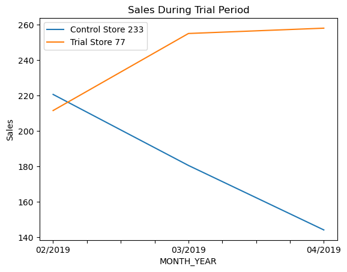

```python
group233['TOT_SALES'].sum().plot(label='Control Store 233')
group77['TOT_SALES'].sum().plot(label='Trial Store 77')
plt.ylabel('Sales')
plt.legend()
plt.title('Sales During Trial Period')
plt.show()
```

| **Store 77** | **Total** |
| --- | --- |
| TOT_SALES | 724.8 |
| PROD_QTY | 219 |
| REPEAT CST | 23 |
| TOTAL CST | 138 |

| **Store 233** | **Total** |
| --- | --- |
| TOT_SALES | 545.5 |
| PROD_QTY | 157 |
| REPEAT CST | 7 |
| TOTAL CST | 108 |

For the first pair we can see a clear difference between the trial store and the control store. every category is higher from total sales to quantity sold, repeat customer, and number of customers

Let's look at the next pair of stores

#### Trial Store 86 and Control Store 155

```python
#Looking at total sales and products sold
tstore_86[['TOT_SALES','PROD_QTY']].sum()
```

```
TOT_SALES    2622.2
PROD_QTY      757.0
dtype: float64
```

```python
#Looking at total sales and products sold
cstore_155[['TOT_SALES','PROD_QTY']].sum()
```

```
TOT_SALES    2418.2
PROD_QTY      690.0
dtype: float64
```

```python
#Looking at total customer transactions
tstore_86[['LYLTY_CARD_NBR']].count()
```

```
LYLTY_CARD_NBR    379
dtype: int64
```

```python
#Looking at total customer transactions
cstore_155[['LYLTY_CARD_NBR']].count()
```

```
LYLTY_CARD_NBR    345
dtype: int64
```

```python
#counting repeat customers that purchased more than once
repeat_customers3 = tstore_86[['LYLTY_CARD_NBR']].value_counts()
print(repeat_customers3.head(111))

repeats_total3=111
```

```
LYLTY_CARD_NBR
86116             5
86112             5
86230             5
86172             5
86075             5
                 ..
86100             2
86025             2
86048             2
86094             2
86097             2
Name: count, Length: 111, dtype: int64
```

```python
#counting repeat customers that purchased more than once
repeat_customers4 = cstore_155[['LYLTY_CARD_NBR']].value_counts()
print(repeat_customers4.head(105))
repeats_total4=105
```

```
LYLTY_CARD_NBR
155048            5
155082            5
155010            5
155153            5
155151            4
                 ..
155319            2
155112            2
155111            2
155116            2
155105            2
Name: count, Length: 105, dtype: int64
```

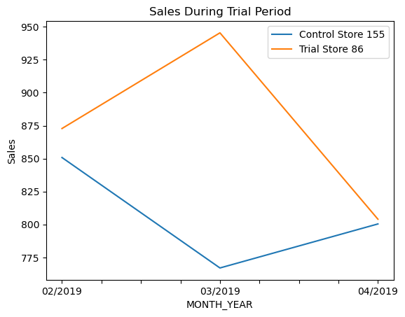

```python
#Grouping stores by month
group86 = tstore_86.groupby('MONTH_YEAR')
group155 = cstore_155.groupby('MONTH_YEAR')

group155['TOT_SALES'].sum().plot(label='Control Store 155')
group86['TOT_SALES'].sum().plot(label='Trial Store 86')
plt.ylabel('Sales')
plt.legend()
plt.title('Sales During Trial Period')
plt.show()
```

| **Store 86** | **Total** |
| --- | --- |
| TOT_SALES | 2622.2 |
| PROD_QTY | 757 |
| REPEAT CST | 111 |
| TOTAL CST | 379 |

| **Store 155** | **Total** |
| --- | --- |
| TOT_SALES | 2418.2 |
| PROD_QTY | 690 |
| REPEAT CST | 105 |
| TOTAL CST | 345 |

For the second pair we can see a clear different between the trial store and the control store. Every category is higher from total sales to quantity sold, repeat customers and numbers of customers

The monthly sales shows a substaintial increase and then a drop for the month of April for the trial store. While the control store declined from Feb to March and had an increase in April

Let's look at the next pair of stores

#### Trial Store 88 and Control Store 237

```python
#Looking at total sales and products sold
tstore_88[['TOT_SALES','PROD_QTY']].sum()
```

```
TOT_SALES    4123.6
PROD_QTY      940.0
dtype: float64
```

```python
#Looking at total sales and products sold
cstore_237[['TOT_SALES','PROD_QTY']].sum()
```

```
TOT_SALES    3644.2
PROD_QTY      826.0
dtype: float64
```

```python
#Looking at total customer transactions
tstore_88[['LYLTY_CARD_NBR']].count()
```

```
LYLTY_CARD_NBR    470
dtype: int64
```

```python
#Looking at total customer transactions
cstore_237[['LYLTY_CARD_NBR']].count()
```

```
LYLTY_CARD_NBR    413
dtype: int64
```

```python
#counting repeat customers that purchased more than once
repeat_customers5 = tstore_88[['LYLTY_CARD_NBR']].value_counts()
print(repeat_customers5.head(138))

repeats_total5=138
```

```
LYLTY_CARD_NBR
88313             6
88231             5
88259             4
88180             4
88111             4
                 ..
88131             2
88033             2
88067             2
88050             2
88128             2
Name: count, Length: 138, dtype: int64
```

```python
#counting repeat customers that purchased more than once
repeat_customers6 = cstore_237[['LYLTY_CARD_NBR']].value_counts()
print(repeat_customers6.head(106))

repeats_total6=106
```

```
LYLTY_CARD_NBR
237366            6
237182            5
237325            5
237038            5
237183            4
                 ..
237262            2
237327            2
237336            2
237072            2
237067            2
Name: count, Length: 106, dtype: int64
```

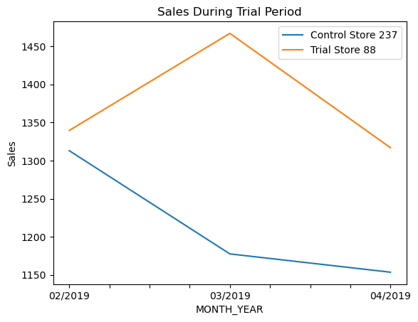

```python
#Grouping stores by month
group88 = tstore_88.groupby('MONTH_YEAR')
group237 = cstore_237.groupby('MONTH_YEAR')

group237['TOT_SALES'].sum().plot(label='Control Store 237')
group88['TOT_SALES'].sum().plot(label='Trial Store 88')
plt.ylabel('Sales')
plt.legend()
plt.title('Sales During Trial Period')
plt.show()
```

[output not shown]

[output not shown]

For the third pair we can see a clear different between the trial store and the control store. Every category is higher from total sales to quantity sold, repeat customers and numbers of customers

It seems that the trial store is outperforming the control store

#### Let's visualize the Product Qty Sold during this period for each group

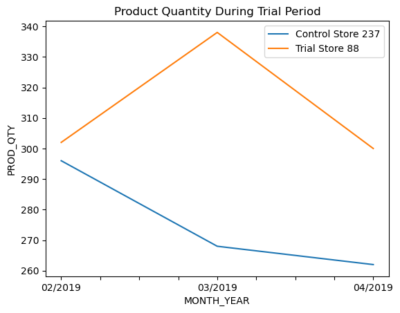

```python
group237['PROD_QTY'].sum().plot(label='Control Store 237')
group88['PROD_QTY'].sum().plot(label='Trial Store 88')
plt.ylabel('PROD_QTY')
plt.legend()
plt.title('Product Quantity During Trial Period')
plt.show()
```

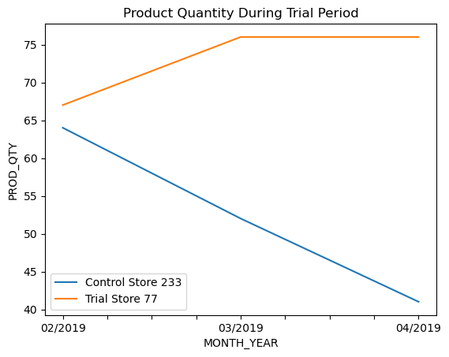

```python
group233['PROD_QTY'].sum().plot(label='Control Store 233')
group77['PROD_QTY'].sum().plot(label='Trial Store 77')
plt.ylabel('PROD_QTY')
plt.legend()
plt.title('Product Quantity During Trial Period')
plt.show()
```

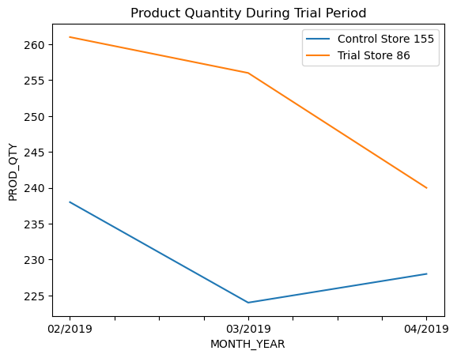

```python
group155['PROD_QTY'].sum().plot(label='Control Store 155')
group86['PROD_QTY'].sum().plot(label='Trial Store 86')
plt.ylabel('PROD_QTY')
plt.legend()
plt.title('Product Quantity During Trial Period')
plt.show()
```

As we can see by the graphs above the trial stores outperformed the control stores every month by quantity sold

#### Let's see how they stack up with average transactions per customers

```python
print('Trial store 77: average transactions per customers: ',group77['LYLTY_CARD_NBR'].value_counts().mean())
print('Control store 233: average transactions per customers: ',group233['LYLTY_CARD_NBR'].value_counts().mean())
print('Trial store 86: average transactions per customers: ',group86['LYLTY_CARD_NBR'].value_counts().mean())
print('Control store 155: average transactions per customers: ',group155['LYLTY_CARD_NBR'].value_counts().mean())
print('Trial store 88: average transactions per customers: ',group88['LYLTY_CARD_NBR'].value_counts().mean())
print('Control store 237: average transactions per customers: ',group237['LYLTY_CARD_NBR'].value_counts().mean())
```

```
Trial store 77: average transactions per customers:  1.037593984962406
Control store 233: average transactions per customers:  1.0384615384615385
Trial store 86: average transactions per customers:  1.2147435897435896
Control store 155: average transactions per customers:  1.25
Trial store 88: average transactions per customers:  1.2566844919786095
Control store 237: average transactions per customers:  1.1766381766381766
```

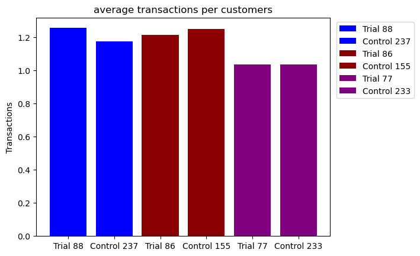

```python
group1 = ['Trial 88','Control 237']
group2 = ['Trial 86','Control 155']
group3 = ['Trial 77','Control 233']
values_group_1 = [1.257,1.177]
values_group_2 = [1.215,1.25]
values_group_3 = [1.038,1.038]

plt.bar(group1,values_group_1,label=group1,color='blue')
plt.bar(group2,values_group_2,label=group2,color='darkred')
plt.bar(group3,values_group_3,label=group3,color='purple')
plt.ylabel('Transactions')
plt.legend(loc='upper right',bbox_to_anchor=(1.3,1))
plt.title('average transactions per customers')
plt.show()
```

## Conclusion

The new layout is working to increase sales